# Analisi di una Rete di Interazioni Proteina-Proteina

Lara Vignotto

## Introduzione

Le reti di interazione proteina-proteina (protein-protein interaction networks, o PPNIs) rappresentano attraverso dei grafi i contatti fisici tra proteine in una cellula. Sono utilizzate per:

- differenziare la fisiologia cellulare tra stati normali e stati di malattia
- raffinare i passaggi di pathway (vie) metabolici
- riconoscere il ruolo di proteine non caratterizzate

Date le limitazioni delle tecniche di rilevamento di interazioni proteina-proteina, i dataset disponibili sono incompleti e “rumorosi”.

## Dataset

Il [dataset](http://yfgdb.princeton.edu/cgi-bin/display.cgi?id=10688190&db=pmid) ([Uetz p., *et al.* (2000)](https://www.nature.com/articles/35001009)) si riferisce all’insieme proteine e interazioni tra esse all’interno di cellule di *S. cerevisiae*, o lievito di birra. È composto da 927 nodi (proteine) e 875 archi (interazioni).

- È vero che le PPNIs posseggono le proprietà tipiche delle reti “reali” (componente gigante, effetto *small world*, distribuzione dei gradi a coda lunga)?
- Qual è il significato biologico di tali proprietà?
- Si possono apprezzare altre caratteristiche?

## Import del dataset

```
##   INTERACTOR_A INTERACTOR_B OFFICIAL_SYMBOL_FOR_A OFFICIAL_SYMBOL_FOR_B
## 1      YOR128C      YOR128C                  ADE2                  ADE2
## 2      YOR128C      YCR066W                  ADE2                 RAD18
## 3      YOR128C      YCR067C                  ADE2                  SED4
## 4      YGR061C      YLR386W                  ADE6                 VAC14
## 5      YDR408C      YOR174W                  ADE8                  MED4
## 6      YDR408C      YGL127C                  ADE8                  SOH1
##   ALIASES_FOR_A ALIASES_FOR_B EXPERIMENTAL_SYSTEM        SOURCE PUBMED_ID
## 1           N/A           N/A          Two-hybrid Uetz P et al.  10688190
## 2           N/A           N/A          Two-hybrid Uetz P et al.  10688190
## 3           N/A           N/A          Two-hybrid Uetz P et al.  10688190
## 4           N/A           N/A          Two-hybrid Uetz P et al.  10688190
## 5           N/A           N/A          Two-hybrid Uetz P et al.  10688190
## 6           N/A         MED31          Two-hybrid Uetz P et al.  10688190
##   ORGANISM_A_ID ORGANISM_B_ID
## 1          4932          4932
## 2          4932          4932
## 3          4932          4932
## 4          4932          4932
## 5          4932          4932
## 6          4932          4932
```

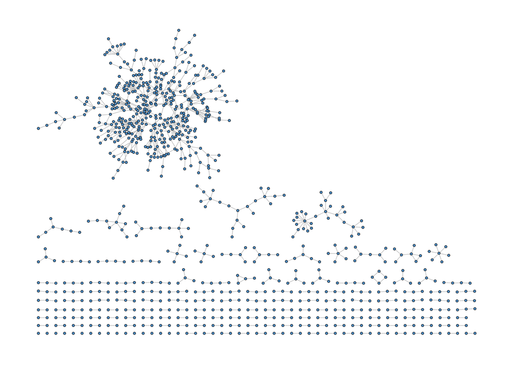

## Componente gigante

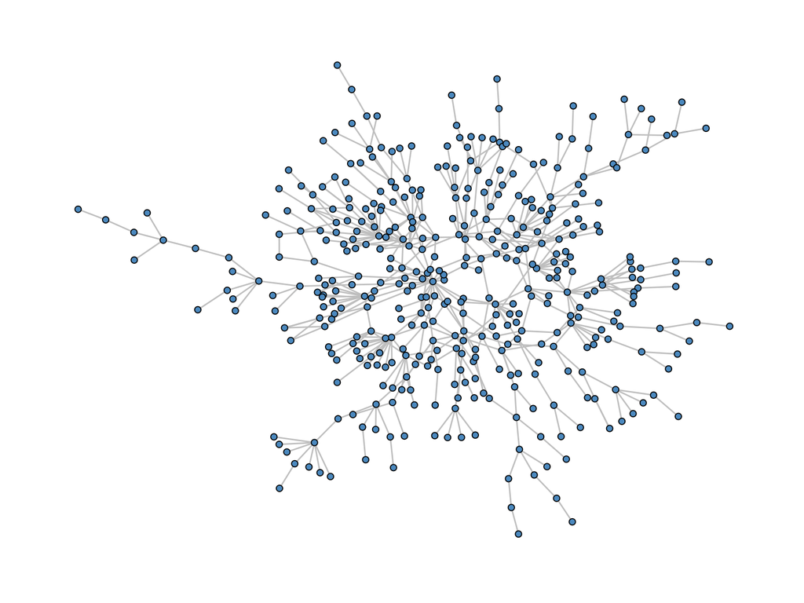

Numero di nodi della rete completa:

```
## [1] 927
```

Numero di nodi della componente gigante:

```
## [1] 415
```

## Degree centrality

I nodi con maggiore e minore numero di vicini:

```
## YML064C YGL212W YDR328C YJR022W YBL026W YMR308C
##      21      15      14      12      11      11
```

```
## YFL056C YLR078C YKR030W YNL146W YBL007C YJR093C
##       1       1       1       1       1       1
```

Il grado medio dei nodi è

```
## [1] 2.395181
```

La distribuzione dei gradi nel grafo:

```
## degree_centrality
##   1   2   3   4   5   6   7   8  10  11  12  14  15  21
## 210  80  45  29  17   9  11   4   3   3   1   1   1   1
```

Rappresentazione grafica:

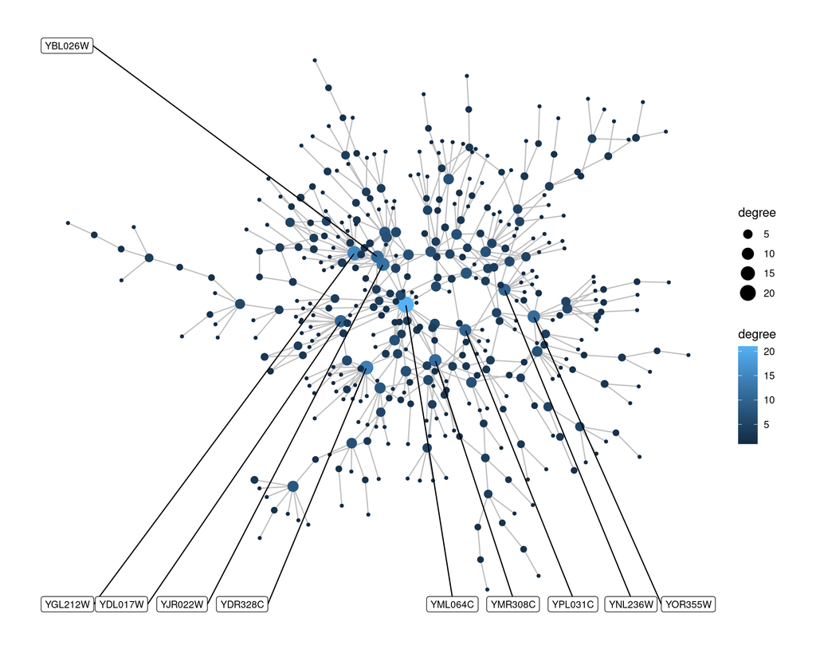

Il nodo con grado maggiore è

```
## YML064C
##      21
```

e i suoi 21 vicini sono

```
##  [1] "YPL049C" "YER179W" "YPR182W" "YDL246C" "YLR423C" "YNL218W" "YPL192C"
##  [8] "YEL015W" "YLR284C" "YJR131W" "YJL058C" "YDR174W" "YOR020C" "YJR159W"
## [15] "YOR229W" "YDR110W" "YKL008C" "YBR171W" "YNL333W" "YHR198C" "YJR056C"
```

Ricercando su [FungiDB](https://fungidb.org/fungidb/app/record/gene/YML064C#CompoundsMetabolicPathways), troviamo che in letteratura le interazioni della proteina *YML064C* sono le seguenti

```
##  [1] "YBR072W" "YBR137W" "YBR171W" "YBR176W" "YDL246C" "YDR110W" "YDR174W"
##  [8] "YEL015W" "YEL066W" "YER179W" "YFR028C" "YGL040C" "YGL221C" "YHR025W"
## [15] "YHR113W" "YHR198C" "YJL058C" "YJL218W" "YJR053W" "YJR056C" "YJR131W"
## [22] "YJR159W" "YKL008C" "YKL035W" "YKL067W" "YKL103C" "YLR284C" "YLR328W"
## [29] "YLR377C" "YLR423C" "YNL044W" "YNL218W" "YNL333W" "YOR020C" "YOR229W"
## [36] "YOR284W" "YPL049C" "YPL111W" "YPL192C" "YPR182W"
```

Verifichiamo che i nodi del grafo adiacenti a *YML064C* siano corretti, ovvero che i nodi vicini trovati appaiano tra le interazioni indicate in letteratura:

```
##  [1] TRUE TRUE TRUE TRUE TRUE TRUE TRUE TRUE TRUE TRUE TRUE TRUE TRUE TRUE TRUE
## [16] TRUE TRUE TRUE TRUE TRUE TRUE
```

Le funzioni cellulari delle proteine con grado maggiore sono:

```
## YML064C YGL212W YDR328C
##      21      15      14
```

- [*YML064C*](https://www.yeastgenome.org/locus/S000004529): coinvolta nella terminazione della fase M della mitosi.
- [*YGL212W*](https://www.yeastgenome.org/locus/S000003180): fa parte del complesso SNARE, che permette l’aggancio dei vacuoli alle membrane cellulari.
- [*YDR328C*](https://www.yeastgenome.org/locus/S000002736): proteina evoluzionalmente conservata presente in vari complessi cellulari. Coinvolta nell’allineamento dei cromosomi lungo il fuso mitotico durante la divisione cellulare.

## Rete *scale-free*

La skewness della distribuzione dei gradi è:

```
## [1] 3.115669
```

La media e la mediana della distribuzione sono:

```
##    Min. 1st Qu.  Median    Mean 3rd Qu.    Max.
##   1.000   1.000   1.000   2.395   3.000  21.000
```

Istogramma della distribuzione dei gradi nel grafo:

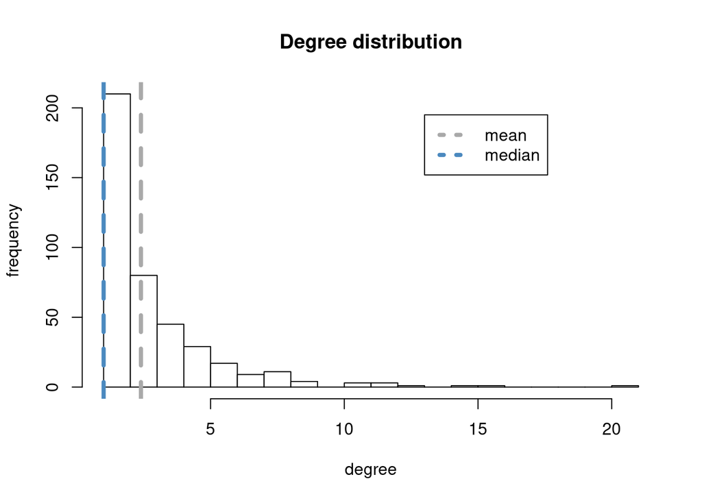

Si può verificare che la distribuzione dei gradi dei nodi segue una legge di potenza graficando la distribuzione stessa in scala logaritmica su entrambi gli assi.

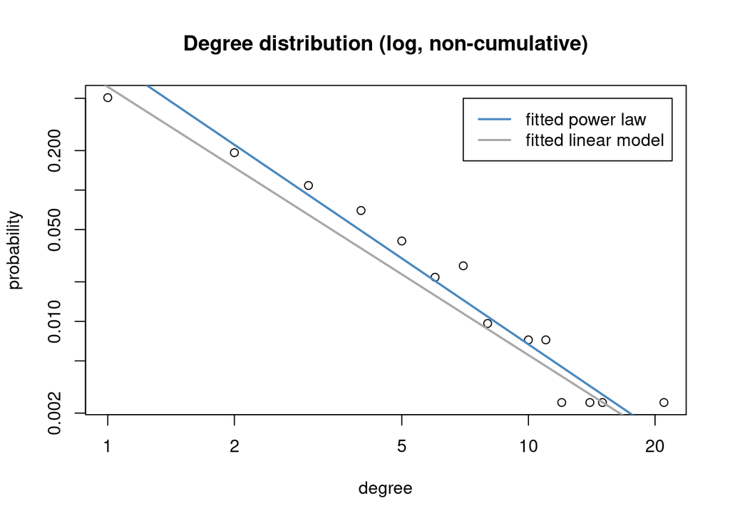

Adattando (*fitting*) una power law alla distribuzione, si ottiene una retta (blu) con *alfa* pari a:

```
## [1] 3.174691
```

```
##    log(x)
## -2.043161
```

Funzione di distribuzione dei gradi, cumulativa:

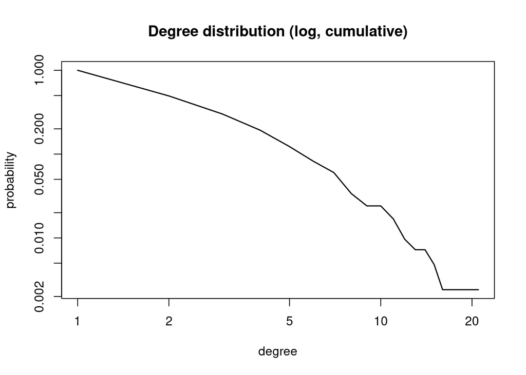

## Effetto *small world*

Numero di nodi del grafo:

```
## [1] 415
```

Distanza media:

```
## [1] 7.43434
```

Distanza massima:

```
## [1] 20
```

Grafici.

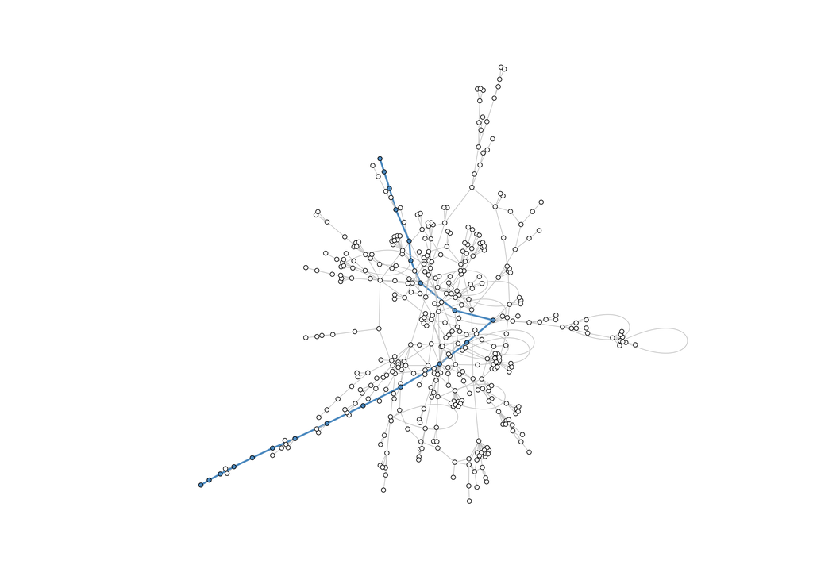

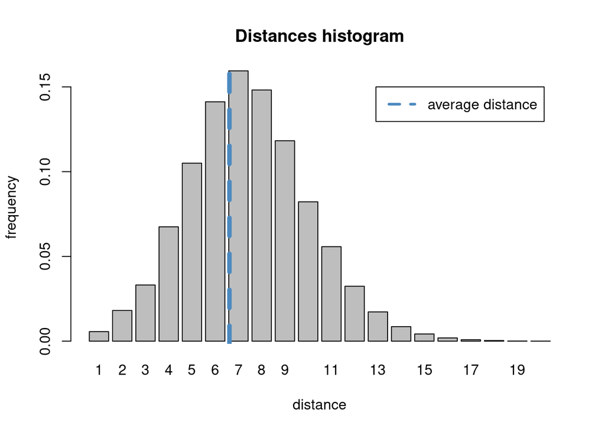